# PTM Enrichment

**Overview**

[figure not shown]

This report visualizes one completed **DPA** enrichment document. The document contains a shared ranked list for every contrast and the results from **PTM-SEA**, **Kinase GSEA**, and **MEA**. Every statistic, membership, and leading edge is decoded from the supplied JSON; this report does not rerun enrichment.

Table 1: PTM enrichment tools, contrasts, tested terms, and terms passing the report FDR threshold.

| Tool | Contrasts | Terms | FDR-significant |
| --- | --- | --- | --- |
| PTM-SEA | 2 | 12 | 10 |
| Kinase GSEA | 2 | 12 | 10 |
| MEA | 2 | 12 | 10 |

**PTM-SEA**

PTM-SEA tests curated kinase, perturbation, pathway, and disease-associated PTM signatures against the DPA site ranking.

**Summary**

Table 2: PTM-SEA result counts by contrast and enrichment direction.

| Contrast | Tested terms | FDR-significant | Positive NES | Negative NES |
| --- | --- | --- | --- | --- |
| a vs b | 6 | 4 | 3 | 1 |
| c vs b | 6 | 6 | 3 | 3 |

**Dot plot**

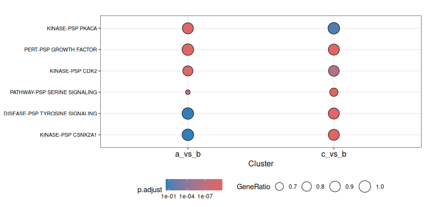

**Heatmap**

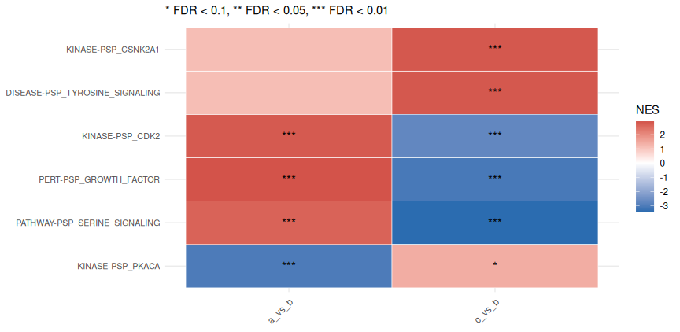

Figure 2: PTM-SEA normalized enrichment scores for the leading signatures across contrasts. Tile colour gives NES and symbols indicate FDR thresholds.

**Volcano**

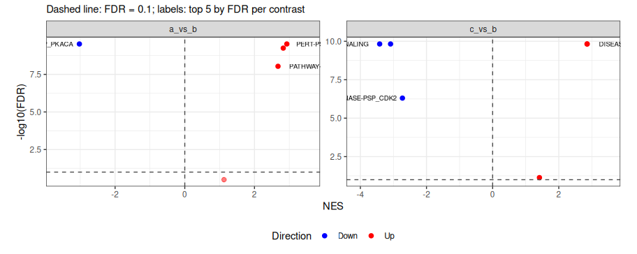

**Rank distributions**

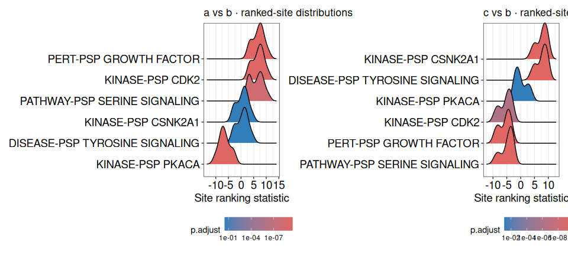

Figure 4: Ranked-site distributions for the leading PTM-SEA signatures. Each ridge shows the ranking statistics of sites belonging to one signature and colour encodes FDR.

**Gene-set network**

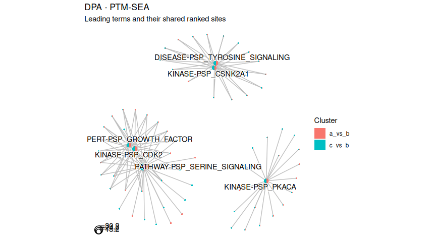

Figure 5: PTM-SEA signature network. Signature nodes connect to their member sites, exposing shared sites across leading terms and contrasts.

**Term similarity**

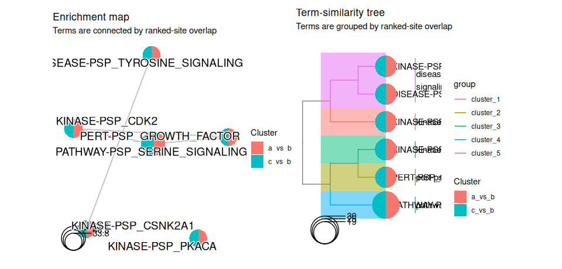

Figure 6: PTM-SEA enrichment map and similarity tree. Signatures are related by overlap among their ranked-site members.

**Results**

Table 3: Complete PTM-SEA result table decoded from the shared JSON document.

| Contrast | Term | NES | FDR | Direction | Mapped sites | Set size | Leading-edge sites |
| --- | --- | --- | --- | --- | --- | --- | --- |
| a vs b | KINASE-PSP_PKACA | -3.025 | 3e-10 | bottom | 18 | 18 | IWLQRRITSLPDKAY;LGAQRRKTAIAMFLH;SQPIRRNTSYRRVRI;GMNLRRFTEIVCQSA;YKSRRRKTEALWKCA;FQLGRRQTHDKAKVE;PIWCRRRTPAPICSK;GVDKRRITKVMPFMA;HKALRRATRSGPWDR;QKAYRRNTADAIRFW;SAFERRITFARPLRA;ALIIRRSTHAAQHVS;AQVWRRST… |
| a vs b | PERT-PSP_GROWTH_FACTOR | 2.929 | 3e-10 | top | 18 | 18 | EAVILLGSPMLVCAC;LGAQSCKSPILVFLH;GMNLFEFSPILVQSA;IWLQKPISPLLVKAY;SQPIRFNSPYLVVRI;YKSRPRKSPALVKCA;FQLGWSQSPDLVKVE;GVDKGKISPVLVFMA;PIWCAKRSPALVCSK;QKAYNLNSPDLVRFW;HKALIKASPSLVWDR;SAFEAGISPALVLRA;AQVWERSS… |
| a vs b | KINASE-PSP_CDK2 | 2.826 | 5.66e-10 | top | 21 | 21 | EAVILLGSPMLVCAC;LGAQSCKSPILVFLH;GMNLFEFSPILVQSA;IWLQKPISPLLVKAY;SQPIRFNSPYLVVRI;YKSRPRKSPALVKCA;FQLGWSQSPDLVKVE;GVDKGKISPVLVFMA;PIWCAKRSPALVCSK;QKAYNLNSPDLVRFW;HKALIKASPSLVWDR;SAFEAGISPALVLRA;AQVWERSS… |
| a vs b | PATHWAY-PSP_SERINE_SIGNALING | 2.675 | 9.16e-09 | top | 36 | 36 | EAVILLGSPMLVCAC;LGAQSCKSPILVFLH;GMNLFEFSPILVQSA;IWLQKPISPLLVKAY;SQPIRFNSPYLVVRI;YKSRPRKSPALVKCA;FQLGWSQSPDLVKVE;GVDKGKISPVLVFMA;PIWCAKRSPALVCSK;QKAYNLNSPDLVRFW;HKALIKASPSLVWDR;SAFEAGISPALVLRA;AQVWERSS… |
| a vs b | DISEASE-PSP_TYROSINE_SIGNALING | 1.126 | 0.319 | top | 18 | 18 | IWDEKPIYSLPDKAY;SQDERFNYSYRRVRI;AQDEERSYSLNVKYS;GMDEFEFYEIVCQSA;MWDESRAYHPSSPLW;YKDEPRKYEALWKCA;EADELLGYVMIHCAC;FQDEWSQYHDKAKVE;LGDESCKYAIAMFLH;PIDEAKRYPAPICSK;GVDEGKIYKVMPFMA;QKDENLNYADAIRFW;ALDEVISY… |
| a vs b | KINASE-PSP_CSNK2A1 | 1.126 | 0.319 | top | 18 | 18 | IWDEKPIYSLPDKAY;SQDERFNYSYRRVRI;AQDEERSYSLNVKYS;GMDEFEFYEIVCQSA;MWDESRAYHPSSPLW;YKDEPRKYEALWKCA;EADELLGYVMIHCAC;FQDEWSQYHDKAKVE;LGDESCKYAIAMFLH;PIDEAKRYPAPICSK;GVDEGKIYKVMPFMA;QKDENLNYADAIRFW;ALDEVISY… |
| c vs b | PATHWAY-PSP_SERINE_SIGNALING | -3.416 | 1.5e-10 | bottom | 36 | 36 | FQLGWSQSHDKAKVE;GVDKGKISKVMPFMA;PIWCAKRSPAPICSK;QKAYNLNSADAIRFW;ALIIVISSPALVHVS;GAQDILISPALVPGP;LPFLNNSSPALVWKK;PVPMIVNSPVLVLRN;ALIIVISSHAAQHVS;GAQDILISMAKAPGP;LPFLNNSSWAYIWKK;PVPMIVNSVVPKLRN;FQLGWSQS… |
| c vs b | PERT-PSP_GROWTH_FACTOR | -3.087 | 1.5e-10 | bottom | 18 | 18 | GAQDILISPALVPGP;LPFLNNSSPALVWKK;PVPMIVNSPVLVLRN;FQLGWSQSPDLVKVE;GVDKGKISPVLVFMA;PIWCAKRSPALVCSK;QKAYNLNSPDLVRFW;GMNLFEFSPILVQSA;IWLQKPISPLLVKAY;SQPIRFNSPYLVVRI;YKSRPRKSPALVKCA;EAVILLGSPMLVCAC;LGAQSCKS… |
| c vs b | DISEASE-PSP_TYROSINE_SIGNALING | 2.857 | 1.5e-10 | top | 18 | 18 | GADEILIYMAKAPGP;HKDEIKAYRSGPWDR;LPDENNSYWAYIWKK;SADEAGIYFARPLRA;EADELLGYVMIHCAC;FQDEWSQYHDKAKVE;LGDESCKYAIAMFLH;PIDEAKRYPAPICSK;AQDEERSYSLNVKYS;GMDEFEFYEIVCQSA;MWDESRAYHPSSPLW;YKDEPRKYEALWKCA;IWDEKPIY… |
| c vs b | KINASE-PSP_CSNK2A1 | 2.857 | 1.5e-10 | top | 18 | 18 | GADEILIYMAKAPGP;HKDEIKAYRSGPWDR;LPDENNSYWAYIWKK;SADEAGIYFARPLRA;EADELLGYVMIHCAC;FQDEWSQYHDKAKVE;LGDESCKYAIAMFLH;PIDEAKRYPAPICSK;AQDEERSYSLNVKYS;GMDEFEFYEIVCQSA;MWDESRAYHPSSPLW;YKDEPRKYEALWKCA;IWDEKPIY… |

[output cut: 2 more lines]

**Kinase GSEA**

Kinase GSEA tests predicted kinase-substrate sets against the same DPA ranked sites.

**Summary**

Table 4: Kinase GSEA result counts by contrast and enrichment direction.

| Contrast | Tested terms | FDR-significant | Positive NES | Negative NES |
| --- | --- | --- | --- | --- |
| a vs b | 6 | 4 | 3 | 1 |
| c vs b | 6 | 6 | 3 | 3 |

**Dot plot**

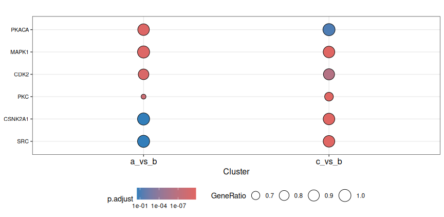

**Heatmap**

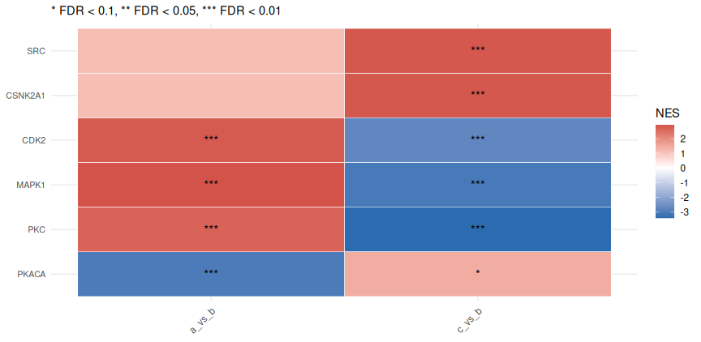

Figure 8: Kinase GSEA normalized enrichment scores for the leading kinases across contrasts. Tile colour gives NES and symbols indicate FDR thresholds.

**Volcano**

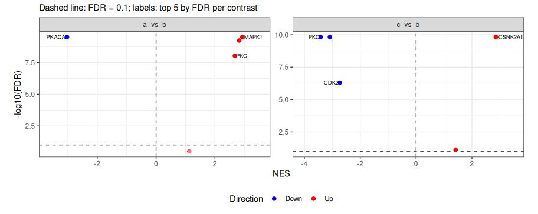

**Rank distributions**

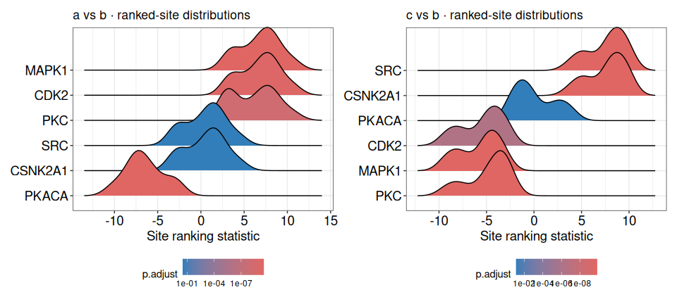

Figure 10: Ranked-site distributions for the leading kinase substrate sets. Each ridge shows the ranking statistics of sites assigned to one kinase and colour encodes FDR.

**Gene-set network**

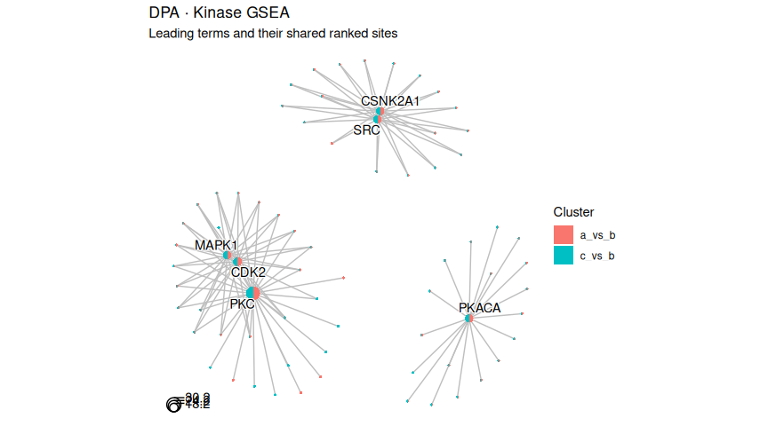

Figure 11: Kinase substrate-set network. Kinase nodes connect to their predicted substrate sites, exposing shared sites across leading kinases and contrasts.

**Term similarity**

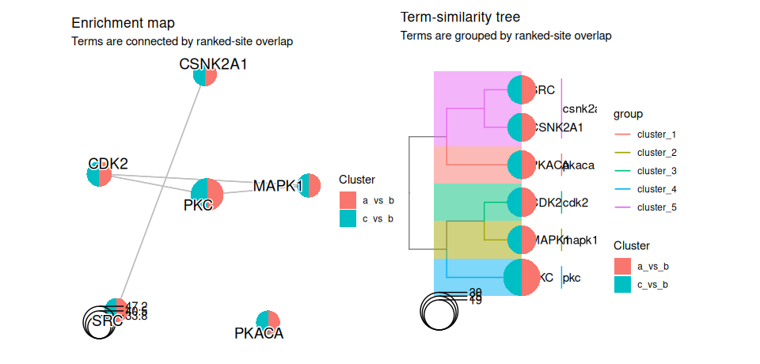

Figure 12: Kinase GSEA enrichment map and similarity tree. Kinases are related by overlap among their predicted substrate sites.

**Results**

Table 5: Complete Kinase GSEA result table decoded from the shared JSON document.

| Contrast | Term | NES | FDR | Direction | Mapped sites | Set size | Leading-edge sites |
| --- | --- | --- | --- | --- | --- | --- | --- |
| a vs b | PKACA | -3.025 | 3e-10 | bottom | 18 | 18 | IWLQRRITSLPDKAY;LGAQRRKTAIAMFLH;SQPIRRNTSYRRVRI;GMNLRRFTEIVCQSA;YKSRRRKTEALWKCA;FQLGRRQTHDKAKVE;PIWCRRRTPAPICSK;GVDKRRITKVMPFMA;HKALRRATRSGPWDR;QKAYRRNTADAIRFW;SAFERRITFARPLRA;ALIIRRSTHAAQHVS;AQVWRRST… |
| a vs b | MAPK1 | 2.929 | 3e-10 | top | 18 | 18 | EAVILLGSPMLVCAC;LGAQSCKSPILVFLH;GMNLFEFSPILVQSA;IWLQKPISPLLVKAY;SQPIRFNSPYLVVRI;YKSRPRKSPALVKCA;FQLGWSQSPDLVKVE;GVDKGKISPVLVFMA;PIWCAKRSPALVCSK;QKAYNLNSPDLVRFW;HKALIKASPSLVWDR;SAFEAGISPALVLRA;AQVWERSS… |
| a vs b | CDK2 | 2.826 | 5.66e-10 | top | 21 | 21 | EAVILLGSPMLVCAC;LGAQSCKSPILVFLH;GMNLFEFSPILVQSA;IWLQKPISPLLVKAY;SQPIRFNSPYLVVRI;YKSRPRKSPALVKCA;FQLGWSQSPDLVKVE;GVDKGKISPVLVFMA;PIWCAKRSPALVCSK;QKAYNLNSPDLVRFW;HKALIKASPSLVWDR;SAFEAGISPALVLRA;AQVWERSS… |
| a vs b | PKC | 2.675 | 9.16e-09 | top | 36 | 36 | EAVILLGSPMLVCAC;LGAQSCKSPILVFLH;GMNLFEFSPILVQSA;IWLQKPISPLLVKAY;SQPIRFNSPYLVVRI;YKSRPRKSPALVKCA;FQLGWSQSPDLVKVE;GVDKGKISPVLVFMA;PIWCAKRSPALVCSK;QKAYNLNSPDLVRFW;HKALIKASPSLVWDR;SAFEAGISPALVLRA;AQVWERSS… |
| a vs b | CSNK2A1 | 1.126 | 0.319 | top | 18 | 18 | IWDEKPIYSLPDKAY;SQDERFNYSYRRVRI;AQDEERSYSLNVKYS;GMDEFEFYEIVCQSA;MWDESRAYHPSSPLW;YKDEPRKYEALWKCA;EADELLGYVMIHCAC;FQDEWSQYHDKAKVE;LGDESCKYAIAMFLH;PIDEAKRYPAPICSK;GVDEGKIYKVMPFMA;QKDENLNYADAIRFW;ALDEVISY… |
| a vs b | SRC | 1.126 | 0.319 | top | 18 | 18 | IWDEKPIYSLPDKAY;SQDERFNYSYRRVRI;AQDEERSYSLNVKYS;GMDEFEFYEIVCQSA;MWDESRAYHPSSPLW;YKDEPRKYEALWKCA;EADELLGYVMIHCAC;FQDEWSQYHDKAKVE;LGDESCKYAIAMFLH;PIDEAKRYPAPICSK;GVDEGKIYKVMPFMA;QKDENLNYADAIRFW;ALDEVISY… |
| c vs b | PKC | -3.416 | 1.5e-10 | bottom | 36 | 36 | FQLGWSQSHDKAKVE;GVDKGKISKVMPFMA;PIWCAKRSPAPICSK;QKAYNLNSADAIRFW;ALIIVISSPALVHVS;GAQDILISPALVPGP;LPFLNNSSPALVWKK;PVPMIVNSPVLVLRN;ALIIVISSHAAQHVS;GAQDILISMAKAPGP;LPFLNNSSWAYIWKK;PVPMIVNSVVPKLRN;FQLGWSQS… |
| c vs b | MAPK1 | -3.087 | 1.5e-10 | bottom | 18 | 18 | GAQDILISPALVPGP;LPFLNNSSPALVWKK;PVPMIVNSPVLVLRN;FQLGWSQSPDLVKVE;GVDKGKISPVLVFMA;PIWCAKRSPALVCSK;QKAYNLNSPDLVRFW;GMNLFEFSPILVQSA;IWLQKPISPLLVKAY;SQPIRFNSPYLVVRI;YKSRPRKSPALVKCA;EAVILLGSPMLVCAC;LGAQSCKS… |
| c vs b | CSNK2A1 | 2.857 | 1.5e-10 | top | 18 | 18 | GADEILIYMAKAPGP;HKDEIKAYRSGPWDR;LPDENNSYWAYIWKK;SADEAGIYFARPLRA;EADELLGYVMIHCAC;FQDEWSQYHDKAKVE;LGDESCKYAIAMFLH;PIDEAKRYPAPICSK;AQDEERSYSLNVKYS;GMDEFEFYEIVCQSA;MWDESRAYHPSSPLW;YKDEPRKYEALWKCA;IWDEKPIY… |
| c vs b | SRC | 2.857 | 1.5e-10 | top | 18 | 18 | GADEILIYMAKAPGP;HKDEIKAYRSGPWDR;LPDENNSYWAYIWKK;SADEAGIYFARPLRA;EADELLGYVMIHCAC;FQDEWSQYHDKAKVE;LGDESCKYAIAMFLH;PIDEAKRYPAPICSK;AQDEERSYSLNVKYS;GMDEFEFYEIVCQSA;MWDESRAYHPSSPLW;YKDEPRKYEALWKCA;IWDEKPIY… |

[output cut: 2 more lines]

**MEA**

MEA reports the native GSEApy kinase-motif enrichment against the same DPA ranked sites. The shared JSON retains its source running scores and hit positions.

**Summary**

Table 6: MEA result counts by contrast and enrichment direction.

| Contrast | Tested terms | FDR-significant | Positive NES | Negative NES |
| --- | --- | --- | --- | --- |
| a vs b | 6 | 4 | 3 | 1 |
| c vs b | 6 | 6 | 3 | 3 |

**Dot plot**

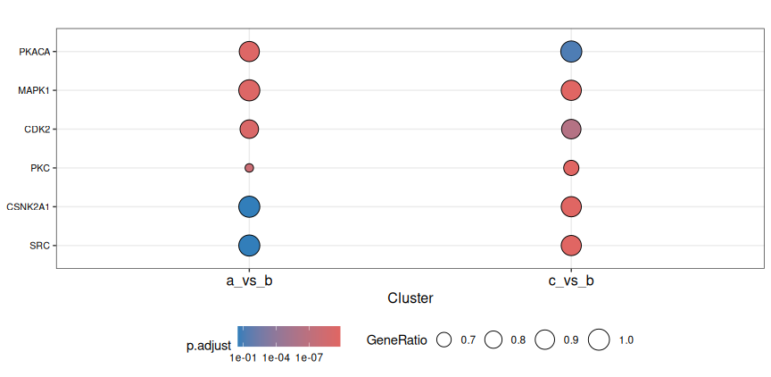

**Heatmap**

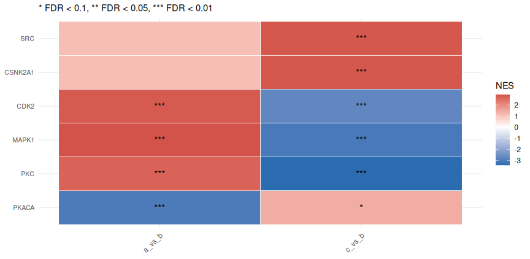

Figure 14: MEA normalized enrichment scores for the leading kinase motifs across contrasts. Tile colour gives NES and symbols indicate FDR thresholds.

**Volcano**

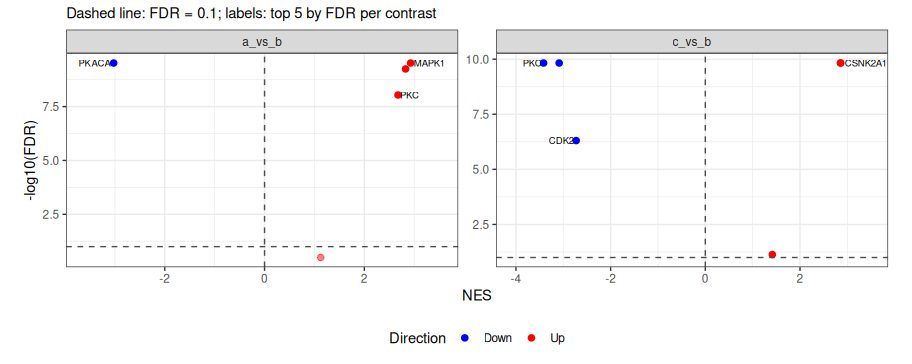

**Rank distributions**

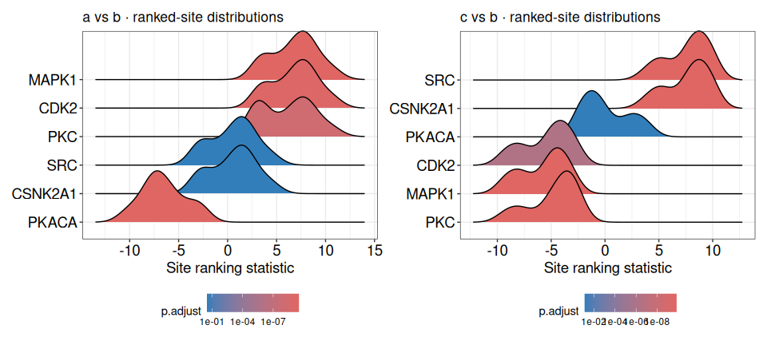

Figure 16: Ranked-site distributions for the leading MEA kinase motifs. Each ridge shows the ranking statistics of substrate sites and colour encodes FDR.

**Gene-set network**

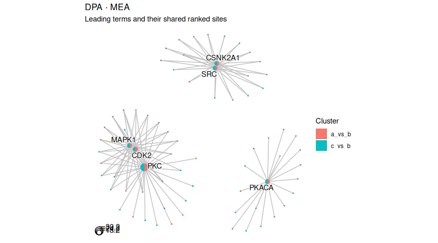

Figure 17: MEA kinase-motif network. Kinase nodes connect to their substrate sites, exposing shared sites across leading motifs and contrasts.

**Term similarity**

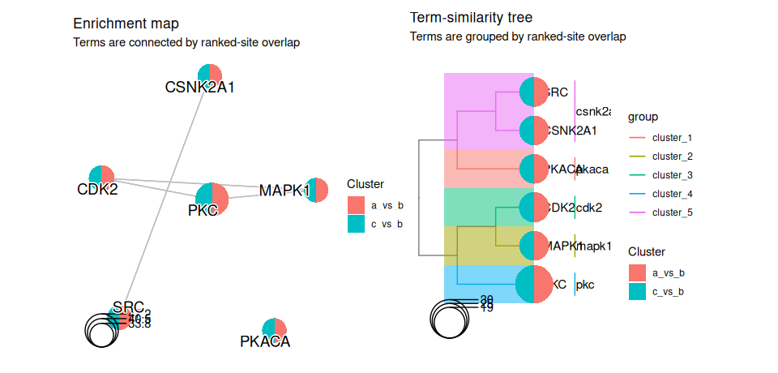

Figure 18: MEA enrichment map and similarity tree. Kinase motifs are related by overlap among their substrate sites.

**Results**

Table 7: Complete MEA result table decoded from the shared JSON document.

| Contrast | Term | NES | FDR | Direction | Mapped sites | Set size | Leading-edge sites |
| --- | --- | --- | --- | --- | --- | --- | --- |
| a vs b | PKACA | -3.025 | 3e-10 | bottom | 18 | 18 | IWLQRRITSLPDKAY;LGAQRRKTAIAMFLH;SQPIRRNTSYRRVRI;GMNLRRFTEIVCQSA;YKSRRRKTEALWKCA;FQLGRRQTHDKAKVE;PIWCRRRTPAPICSK;GVDKRRITKVMPFMA;HKALRRATRSGPWDR;QKAYRRNTADAIRFW;SAFERRITFARPLRA;ALIIRRSTHAAQHVS;AQVWRRST… |
| a vs b | MAPK1 | 2.929 | 3e-10 | top | 18 | 18 | EAVILLGSPMLVCAC;LGAQSCKSPILVFLH;GMNLFEFSPILVQSA;IWLQKPISPLLVKAY;SQPIRFNSPYLVVRI;YKSRPRKSPALVKCA;FQLGWSQSPDLVKVE;GVDKGKISPVLVFMA;PIWCAKRSPALVCSK;QKAYNLNSPDLVRFW;HKALIKASPSLVWDR;SAFEAGISPALVLRA;AQVWERSS… |
| a vs b | CDK2 | 2.826 | 5.66e-10 | top | 21 | 21 | EAVILLGSPMLVCAC;LGAQSCKSPILVFLH;GMNLFEFSPILVQSA;IWLQKPISPLLVKAY;SQPIRFNSPYLVVRI;YKSRPRKSPALVKCA;FQLGWSQSPDLVKVE;GVDKGKISPVLVFMA;PIWCAKRSPALVCSK;QKAYNLNSPDLVRFW;HKALIKASPSLVWDR;SAFEAGISPALVLRA;AQVWERSS… |
| a vs b | PKC | 2.675 | 9.16e-09 | top | 36 | 36 | EAVILLGSPMLVCAC;LGAQSCKSPILVFLH;GMNLFEFSPILVQSA;IWLQKPISPLLVKAY;SQPIRFNSPYLVVRI;YKSRPRKSPALVKCA;FQLGWSQSPDLVKVE;GVDKGKISPVLVFMA;PIWCAKRSPALVCSK;QKAYNLNSPDLVRFW;HKALIKASPSLVWDR;SAFEAGISPALVLRA;AQVWERSS… |
| a vs b | CSNK2A1 | 1.126 | 0.319 | top | 18 | 18 | IWDEKPIYSLPDKAY;SQDERFNYSYRRVRI;AQDEERSYSLNVKYS;GMDEFEFYEIVCQSA;MWDESRAYHPSSPLW;YKDEPRKYEALWKCA;EADELLGYVMIHCAC;FQDEWSQYHDKAKVE;LGDESCKYAIAMFLH;PIDEAKRYPAPICSK;GVDEGKIYKVMPFMA;QKDENLNYADAIRFW;ALDEVISY… |
| a vs b | SRC | 1.126 | 0.319 | top | 18 | 18 | IWDEKPIYSLPDKAY;SQDERFNYSYRRVRI;AQDEERSYSLNVKYS;GMDEFEFYEIVCQSA;MWDESRAYHPSSPLW;YKDEPRKYEALWKCA;EADELLGYVMIHCAC;FQDEWSQYHDKAKVE;LGDESCKYAIAMFLH;PIDEAKRYPAPICSK;GVDEGKIYKVMPFMA;QKDENLNYADAIRFW;ALDEVISY… |
| c vs b | PKC | -3.416 | 1.5e-10 | bottom | 36 | 36 | FQLGWSQSHDKAKVE;GVDKGKISKVMPFMA;PIWCAKRSPAPICSK;QKAYNLNSADAIRFW;ALIIVISSPALVHVS;GAQDILISPALVPGP;LPFLNNSSPALVWKK;PVPMIVNSPVLVLRN;ALIIVISSHAAQHVS;GAQDILISMAKAPGP;LPFLNNSSWAYIWKK;PVPMIVNSVVPKLRN;FQLGWSQS… |
| c vs b | MAPK1 | -3.087 | 1.5e-10 | bottom | 18 | 18 | GAQDILISPALVPGP;LPFLNNSSPALVWKK;PVPMIVNSPVLVLRN;FQLGWSQSPDLVKVE;GVDKGKISPVLVFMA;PIWCAKRSPALVCSK;QKAYNLNSPDLVRFW;GMNLFEFSPILVQSA;IWLQKPISPLLVKAY;SQPIRFNSPYLVVRI;YKSRPRKSPALVKCA;EAVILLGSPMLVCAC;LGAQSCKS… |
| c vs b | CSNK2A1 | 2.857 | 1.5e-10 | top | 18 | 18 | GADEILIYMAKAPGP;HKDEIKAYRSGPWDR;LPDENNSYWAYIWKK;SADEAGIYFARPLRA;EADELLGYVMIHCAC;FQDEWSQYHDKAKVE;LGDESCKYAIAMFLH;PIDEAKRYPAPICSK;AQDEERSYSLNVKYS;GMDEFEFYEIVCQSA;MWDESRAYHPSSPLW;YKDEPRKYEALWKCA;IWDEKPIY… |
| c vs b | SRC | 2.857 | 1.5e-10 | top | 18 | 18 | GADEILIYMAKAPGP;HKDEIKAYRSGPWDR;LPDENNSYWAYIWKK;SADEAGIYFARPLRA;EADELLGYVMIHCAC;FQDEWSQYHDKAKVE;LGDESCKYAIAMFLH;PIDEAKRYPAPICSK;AQDEERSYSLNVKYS;GMDEFEFYEIVCQSA;MWDESRAYHPSSPLW;YKDEPRKYEALWKCA;IWDEKPIY… |

[output cut: 2 more lines]

**About methods**

**Reading the results**

**TipNES, FDR, and leading edge**

All three methods test sets of phosphosites against the same ranked contrast. A positive normalized enrichment score (**NES**) means the set is concentrated near the positive end of the ranking; a negative NES means concentration near the negative end. The **FDR** corrects for the many tested sets. The **leading-edge sites** are the subset that contributes most strongly to the enrichment score.

The sign describes the direction of the ranked site-level effect. Its biological meaning therefore follows the analysis supplied to this report: DPA, DPU, or CorrectFirst DPU.

**PTM-SEA**

**NoteCurated PTM signatures**

PTM-SEA tests PTMsigDB signatures, including curated kinase substrates, pathways, perturbations, and disease-associated PTM sets. The sites are ordered by the analysis statistic and tested with pre-ranked GSEA. A significant NES indicates coordinated movement of sites belonging to that curated signature.

PTM-SEA is useful when a biological process or known kinase-substrate signature is represented in PTMsigDB. Coverage is limited to annotated sites.

**Kinase GSEA**

**NotePredicted kinase-substrate sets**

Kinase GSEA uses Kinase Library sequence-motif assignments as gene sets, then tests those sets against the ranked sites with clusterProfiler’s GSEA backend. One site can be assigned to several kinases because related kinases can prefer similar sequence motifs.

The result supports a kinase-activity hypothesis based on coordinated substrate behaviour. It does not measure kinase abundance or prove a direct kinase-substrate relationship.

**MEA**

**NoteNative motif enrichment analysis**

MEA scores each site’s ±7-residue sequence window with the Python Kinase Library models, forms a predicted substrate set for each kinase at the configured motif percentile, and runs pre-ranked enrichment with GSEApy. The JSON preserves the native MEA statistics and site membership used in this report.

Kinases in the same family often have highly overlapping motifs. MEA can therefore indicate an active motif class more strongly than one uniquely identified kinase.

**Session Info**

**Report provenance**

Table 8: Input document, report parameters, package version, and render timestamp.

| Field | Value |
| --- | --- |
| Analysis | DPA |
| Input JSON | /home/runner/work/_temp/Library/protsea/extdata/PTM_DPA_gsea_result.json.gz |
| Contrasts | a_vs_b; c_vs_b |
| Tools | PTM-SEA; Kinase GSEA; MEA |
| FDR threshold | 0.1 |
| Top terms per summary plot | 10 |
| Report package | protsea 0.1.0 |
| Generated at | 2026-09-26 19:30:57 UTC |
| Qmd source | PTM_enrichment.qmd |

## Download

- Qmd source
- HTML page

Select all plots

Plots download at the resolution embedded in the report (its fig-dpi). Interactive (plotly) charts aren't listed — export those from their own toolbar.